# 2. Introduction section charts

Author

Sagar Shah, Rethink Priorities

Published

February 7, 2024

# Prep

Clear memory and load files

# Load and process data

I first input a [spreadsheet](https://perma.cc/VB99-T48E) from fishcount.org, providing estimates of the mean slaughter weight and mean lifespan of the 24 most commonly farmed finfish species.

```r
lifeexp <-
  # Read file
  read_excel(
              "../1_input_data/fishcount_living.xlsx",
              range = "A9:V33") |>
  # Select collumns needed
          select(1,9:10,13:14) %>%
  # Convert collumn names to lower case
          mutate(across(1,str_to_lower))

# Rename collumns
names(lifeexp) <- c("species","weight_lower","weight_upper","lifespan_lower","lifespan_upper")

lifeexp
```

```
# A tibble: 24 × 5
   species               weight_lower weight_upper lifespan_lower lifespan_upper
   <chr>                        <dbl>        <dbl>          <dbl>          <dbl>
 1 grass carp(=white am…          500         2500             12             24
 2 silver carp                    300         1500             24             24
 3 common carp                    500         2500             10             48
 4 nile tilapia                   250          800              6              7
 5 bighead carp                   500         1500             14             28
 6 carassius spp                  150          400             12             19
 7 catla                          300         2000             14             21
 8 atlantic salmon               3614         8434             22             27
 9 roho labeo                     300         1500             14             21
10 pangas catfishes nei           500         1500             10             14
# ℹ 14 more rows
```

I then select the species I’m interested in (based on consumption in the EU).

```r
#Define search terms to filter collumns
species_list <- c("common carp","pangas","north african","trout",
                  "seabream","seabass","salmon","tilapia","striped") %>%
                  paste(collapse="|")

# Filter collumns based on search terms
lifeexp %<>% filter(str_detect(species,species_list))

# Assign each species line to a species group
species_data<- lifeexp %>%
mutate(
  species_group=case_when(
    str_detect(species,"carp") ~ "Common Carp",
    str_detect(species,"salmon") ~ "Salmon",
    str_detect(species,"catfish") ~ "Freshwater Catfish",
    str_detect(species,"trout") ~ "Rainbow Trout",
    str_detect(species,"seabream") ~ "Gilthead Seabream",
    str_detect(species,"seabass") ~ "European Seabass",
    str_detect(species,"tilapia") ~ "Tilapia",
    TRUE ~ "ERROR"
  )
) %>%

# Order rows by species group
  relocate(species_group) %>%
  arrange(species_group)

# Calculate upper/lower/average weights and lifespans across all species within a species group
species_data  %<>%
  group_by(species_group) %>%
  summarise(
    weight_lower=min(weight_lower),
    weight_upper=max(weight_upper),
    weight_av=(min(weight_lower)+max(weight_upper))/2,
    lifespan_lower=min(lifespan_lower),
    lifespan_upper=max(lifespan_upper),
    lifespan_av=(min(lifespan_lower)+max(lifespan_upper))/2
  )

species_data
```

```
# A tibble: 7 × 7
  species_group      weight_lower weight_upper weight_av lifespan_lower
  <chr>                     <dbl>        <dbl>     <dbl>          <dbl>
1 Common Carp                 500         2500      1500             10
2 European Seabass            400          500       450             14
3 Freshwater Catfish          500         1500      1000             10
4 Gilthead Seabream           300          400       350             12
5 Rainbow Trout               210         5000      2605              9
6 Salmon                     3614         8434      6024             22
7 Tilapia                     250          800       525              6
# ℹ 2 more variables: lifespan_upper <dbl>, lifespan_av <dbl>
```

I then supplement the fishcount data with my own figures where I think I have better numbers in the EU context than those provided by fishcount.

- (Small) Rainbow trout - Add in a median expected weight of 500g rather than the mid-point, given number of lives is likely to skew more heavily towards smaller weights given consumption is dominated by weight in countries consuming smaller trout. Used longer life expectancy based on [Jokumsen & Svendsen (2010)](https://perma.cc/T3NM-FKRL), [Animal Ask Denmark report](https://www.animalask.org/post/farmed-fish-advocacy-in-denmark), and [EUMOFA case study](https://perma.cc/G47F-CS6P).
- (Large) Rainbow Trout - Used longer life expectancy based on [Animal Ask Denmark report](https://www.animalask.org/post/farmed-fish-advocacy-in-denmark) and [EUMOFA case study](https://perma.cc/XV5N-6B5R), and various websites suggesting around 1.5 years during on-growing phase to achieve harvest weight.
- Atlantic Salmon - Used mean weight from [Norwegian Fish Health](https://perma.cc/FZF4-GYPU) report average slaughter weight and number of smolts put out to sea. Used life expectancy based on [Mowi Industry report](https://perma.cc/5BLM-5EB4).
- Carp - Used data from [EUMOFA report](https://perma.cc/G9K7-WY3X) suggesting typical weights for consumption is 1.5 to 2kg, and typically 3 year production cycle. Small carp seem less commonly consumed in EU.

```r
species_data %<>%
  rbind(
   c("Rainbow Trout (small)",210,1200,500,12,15,13.5),
  c("Rainbow Trout (large)",1200,5000,3100,21,26,23.5),
  c("Atlantic Salmon",3614,8434,5663,22,40,31),
  c("Carp",1250,2250,1750,30,42,36)
  ) %>%
    mutate(across(2:7,as.double))

species_data
```

```
# A tibble: 11 × 7
   species_group         weight_lower weight_upper weight_av lifespan_lower
   <chr>                        <dbl>        <dbl>     <dbl>          <dbl>
 1 Common Carp                    500         2500      1500             10
 2 European Seabass               400          500       450             14
 3 Freshwater Catfish             500         1500      1000             10
 4 Gilthead Seabream              300          400       350             12
 5 Rainbow Trout                  210         5000      2605              9
 6 Salmon                        3614         8434      6024             22
 7 Tilapia                        250          800       525              6
 8 Rainbow Trout (small)          210         1200       500             12
 9 Rainbow Trout (large)         1200         5000      3100             21
10 Atlantic Salmon               3614         8434      5663             22
11 Carp                          1250         2250      1750             30
# ℹ 2 more variables: lifespan_upper <dbl>, lifespan_av <dbl>
```

I now input data on apparent consumption of the most consumed farmed finfish species in the EU27 in 2021, taken from [supply balance sheet data from EUMOFA](https://eumofa.eu/supply-balance-sheet).

Splits between large and small rainbow trout are based on the [EUMOFA large trout case study](https://perma.cc/XV5N-6B5R).

```r
eu_consumption_2021 <- tibble(
# Define species names
  species_group=c('Atlantic Salmon',"Rainbow Trout",'Rainbow Trout (large)',"Rainbow Trout (small)",'Gilthead Seabream','European Seabass','Freshwater Catfish','Carp','Tilapia'),
# Add consupmtion in metric tonnes
  consumption=c(1097029,216425,94033,122392,136724,106776,102039,79726,39833)) %>%
# Convert to grammes (as fish weight reported in grammes)
  mutate(consumption=consumption*1E6)

eu_consumption_2021
```

```
# A tibble: 9 × 2
  species_group           consumption
  <chr>                         <dbl>
1 Atlantic Salmon       1097029000000
2 Rainbow Trout          216425000000
3 Rainbow Trout (large)   94033000000
4 Rainbow Trout (small)  122392000000
5 Gilthead Seabream      136724000000
6 European Seabass       106776000000
7 Freshwater Catfish     102039000000
8 Carp                    79726000000
9 Tilapia                 39833000000
```

I then add in the data with species specific data and work out number of animals slaughtered and age.

```r
eu_consumption_2021 %<>%
# Add fish weight and lifespan data
  left_join(species_data,by="species_group") %>%
  rowwise() %>%
  mutate(
# Number of fish slaughtered figures
    slaughter_upper=consumption/weight_lower,
    slaughter_lower=consumption/weight_upper,
    slaughter_midweight=consumption/weight_av,
# Lifespan ranges, assuming perfect correlation between weight and lifespan ranges
    lifeyears_1=consumption/weight_lower*lifespan_lower/12,
    lifeyears_2=consumption/weight_upper*lifespan_upper/12,
# Min and max lifespan
    lifeyears_lower=min(lifeyears_1,lifeyears_2),
    lifeyears_upper=max(lifeyears_1,lifeyears_2),
# Best guess of average lifespan
    lifeyears_midwl=slaughter_midweight*lifespan_av/12
  )
```

# Fig1: Number of fish slaughtered for EU consumption

Construct chart

```r
fig1 <-   eu_consumption_2021 %>%
  filter(species_group!="Rainbow Trout") %>%
  ggplot(
    aes(
      x=reorder(str_to_title(species_group),slaughter_midweight),
      y=slaughter_midweight,
      ymin=slaughter_lower,
      ymax=slaughter_upper
    )
  ) +
  geom_col(fill="#1B9E77")+
  geom_errorbar(width=0.2,size=0.3)+
    scale_y_continuous(labels = scales::label_number_si()) +
  theme_light() +
  coord_flip() +
    labs(
    title="Number of fish slaughtered",
    subtitle="Farmed finfish to support EU27 consumption in 2021",
    y="Number slaughtered",
    x="")
```

Print chart

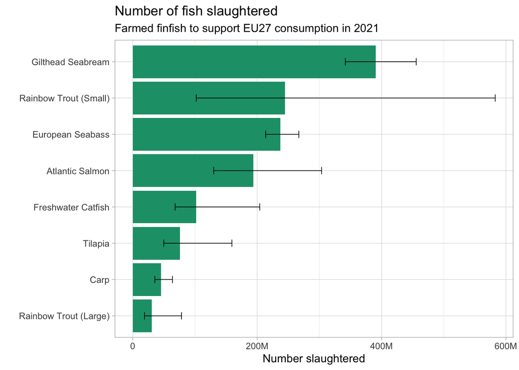

```r
  fig1
```

# Fig 2: Share of EU farms where fish are stunned before slaughter

Source: Leaked EU impact assessment document

Construct chart

```r
share_stunned <- tibble(
  species=c("Atlantic Salmon","Rainbow Trout","Carp","Seabream & Seabass"),
  upper=c(1,0.5,0.1,0.05),
  lower=c(0.9,0.2,0,0),
  label=c("> 90%","20% to 50%","< 10%","< 5%")) %>%
  mutate(label_pos=0.5*(upper+lower))



fig2 <- share_stunned %>%
  ggplot(
    aes(
      x=reorder(species,upper),
      ymin=lower,
      y=label_pos,
      ymax=upper
    )
  ) +
  geom_errorbar(width=0.5,size=1)+
  geom_linerange(size=8,color="#1B9E77") +
  geom_text(aes(label=label),nudge_x=0.38) +
  scale_y_continuous(labels = scales::percent) +
  theme_light() +
  coord_flip() +
    labs(
    title="Share of EU farms where fish are stunned",
    x="",
    y="")
```

Print chart

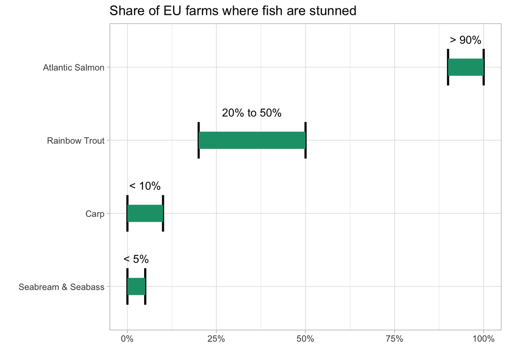

```r
fig2
```

# Fig 3 - Consumption by country

Construct chart

```r
fig_3_data <-
readRDS("../3_intermediate_data/cons_data.rds") %>%
  filter(country!="United Kingdom") %>%
  mutate(species_group=case_when(
    str_detect(species,"Sea Bream") ~ "Gilthead Seabream",
    str_detect(species,"Sea Bass") ~ "European Seabass",
    str_detect(species,"Salmon") ~ "Atlantic Salmon",
    str_detect(species,"Small") ~ "Rainbow Trout (small)",
    str_detect(species,"Large") ~ "Rainbow Trout (large)",
    str_detect(species,"Carp") ~ "Carp",
    TRUE~"Error")) %>%
  left_join(species_data,by="species_group") %>%
  mutate(
    slaughter_midweight=tons*1E6/weight_av) %>%
  select(species_group,country,slaughter_midweight) %>%
  group_by(country) %>%
  mutate(
    total_cons=sum(slaughter_midweight)
  ) %>%
  ungroup()
```

```r
fig3 <- fig_3_data %>%
  filter(!species_group %in% c("Atlantic Salmon","Carp","Rainbow Trout (large)")) %>%
  group_by(country) %>%
  mutate(
    total_cons=sum(slaughter_midweight)
  ) %>%
  ungroup() %>%
ggplot(aes(
      y=reorder(country,total_cons),
      x=slaughter_midweight,
      fill=species_group))+
    geom_col()+
    labs(
    title = "Annual number of farmed fish slaughtered to support consumption in EU27",
    x = "Estimated number of individual fish (\"mid-point estimate\")",
    y = "",
    fill = "Species"
  ) +
  scale_x_continuous(labels = label_number(suffix = "M", scale = 1e-6)) +
  scale_fill_brewer(palette = "Dark2",
                    labels = c("European Seabass (2016)", "Gilthead Seabream (2019)", "Small Rainbow Trout (2020)")) +
  theme_light() +
  theme(legend.position = "right")
```

Print chart

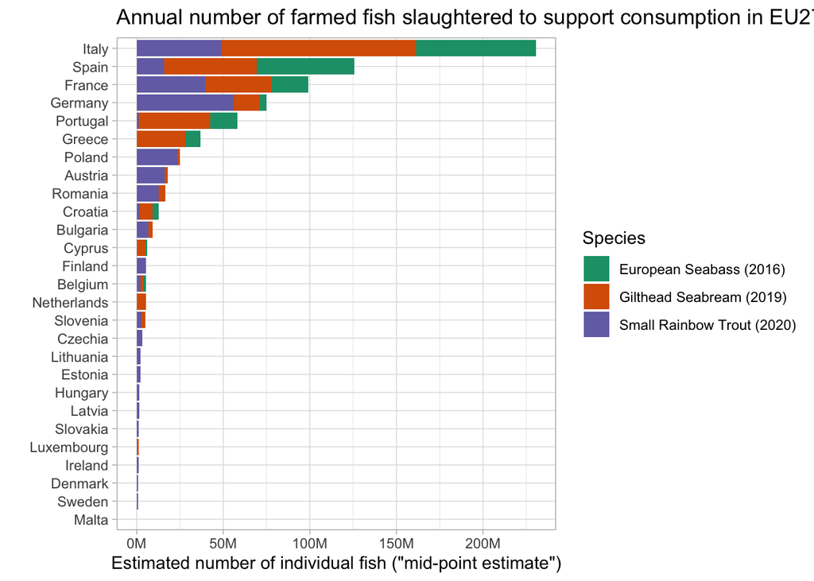

```r
fig3
```

# Export charts into .png format

```r
save_chart("fig1_eu_slaughter_numbers.png",fig1)
save_chart("fig2_stun_shares.png",fig2)
save_chart("fig3_slaughter_by_country_consumption.png",fig3)
```